# Analyzing Gas Price Dynamics: California and Beyond

As of December 8, 2023

Jordan Le

# Overview

## Curosity and Interest

Recently, a friend visiting from out of state mentioned filling up their gas tank in Texas for $2.70, leaving me astonished considering the $5.00 to $6.00 average prices in my area. This interaction sparked my curiosity about gas prices over the years, especially when compared to other parts of the United States. Having lived in California my entire life, I’ve witnessed the rise in gas prices since I started driving in 2012. This curiosity led me to explore gas prices for a capstone project as I delve into data analytics and pursue my certificate in the field.

## Scope

The project aims to analyze gas price trends and disparities across regions in the United States, including the Coast, Midwest, and East Coast. Additionally, the focus will be on comparing gas prices in California to the broader West Coast.

## Objective

Utilize historical gas price data to create visualizations and compare the U.S. average price to each region from 2000 to 2023. The primary focus will be on Regular-grade gas, and specific attention will be given to California for in-depth comparisons.

# The Six Data Analysis Phases

## Ask

Questions being asked for this project:

1. What is the trend of gas prices in the United States from the 2000 to 2023?
2. What are the main differences in price disparity between the West Coast, Midwest, and East Coast? How does it compare to the average gas price in the U.S.?
3. How do California gas prices compare to the West Coast prices in general?
4. Do gas prices tend to exhibit noticeable fluctuations during the year in California? If so, are there any patterns in gas that consumers can leverage for cost savings?

## Prepare

Data collection and source:

Source: www.eia.gov (Energy Information Administration)

- Analyze U.S regular gasoline prices in U.S. dollars/ per gallon.
- Utilizing the availability of government data to export to an excel sheet.

Excel File Name: pswrgvwall.xls

[Available from Website](http://www.eia.gov/oil_gas/petroleum/data_publications/wrgp/mogas_history.htm)

## Process

Step by step process on actions to clean data:

1. Determine the dataset being used.
   - Focus on primarily Regular All Area All Formulations dataset.
2. Take dataset and export it to a new sheet.
3. Determine required data for the project.
   - West Coast, Midwest, East Coast, Historical U.S. prices, California.
4. Determine time frame for analysis for the data.
   - Start date: January 3, 2000.
   - End date: December 8, 2023.
5. Delete rows of data leading up to the year 2000s to avoid any calculation conflicts.
6. Cleaning data:
   - Handle missing values:
     - Find and Replace empty cells with N/A.
   - Remove duplicates:
     - No duplicates found.
   - Deleting rows of data:
     - Data from 1990 onward to 2000 available and removed.
   - Formatting:
     - Changed date format to year-month-day format.
   - Check if data is consistent:
     - use the subtraction function to see if the date is correct.
     - every week/7 day updated.
     - use filter to see if there are any days that are incorrect.
   - Data consistency:
     - converting numbers into dollar values.
     - rounding values up or down.

## Analyze

[Link to raw and clean dataset here](https://github.com/QrowninJL/Case-Study-Gas-Price-Comparison/tree/main/dataset)

Tools and programs utilized:

- Excel Sheets
- Tableau
- Rstudio

Data is cleaned and ready to be analyzed. To answer the questions above, we will create visualizations using tools from the programs above to help answer the questions.

Questions:

1. What is the trend of gas prices in the United States from the 2000 to 2023?
   - Excel Sheets - line graph comparison.
   - Sort and filter for the years 2000-2023.
2. What are the main differences in price disparity between the West Coast, Midwest, and East Coast? How does it compare to the average gas price in the U.S.?
   - Excel Sheets - line graph comparison.
   - Examine price disparity by the difference in the line.
3. How do California gas prices compare to the West Coast prices in general?
   - Tableau - bar graph comparison.
   - View bar graph and calculate difference between price ranges between the two.
4. Do gas prices tend to exhibit noticeable fluctuations during the year in California? If so, are there any patterns in gas that consumers can leverage for cost savings?
   - Tableau - Individual line graph comparing per year.
   - Compare and contrast the trend line between the years 2020-2023.

## Share

Visualizations created from Tableau and Exceel:

### Average Gas Prices and Line Chart 2000-2023

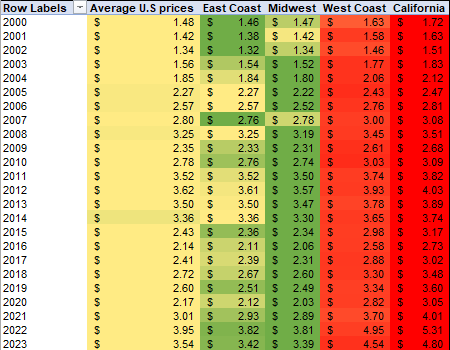

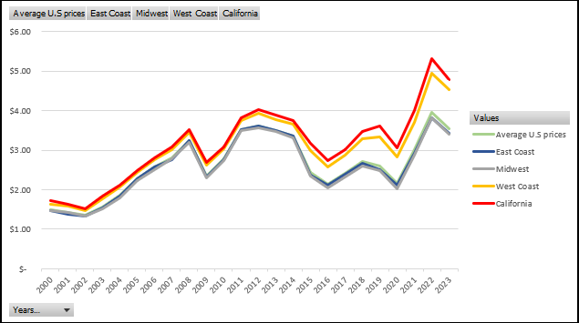

### Bar Chart - California and West Coast

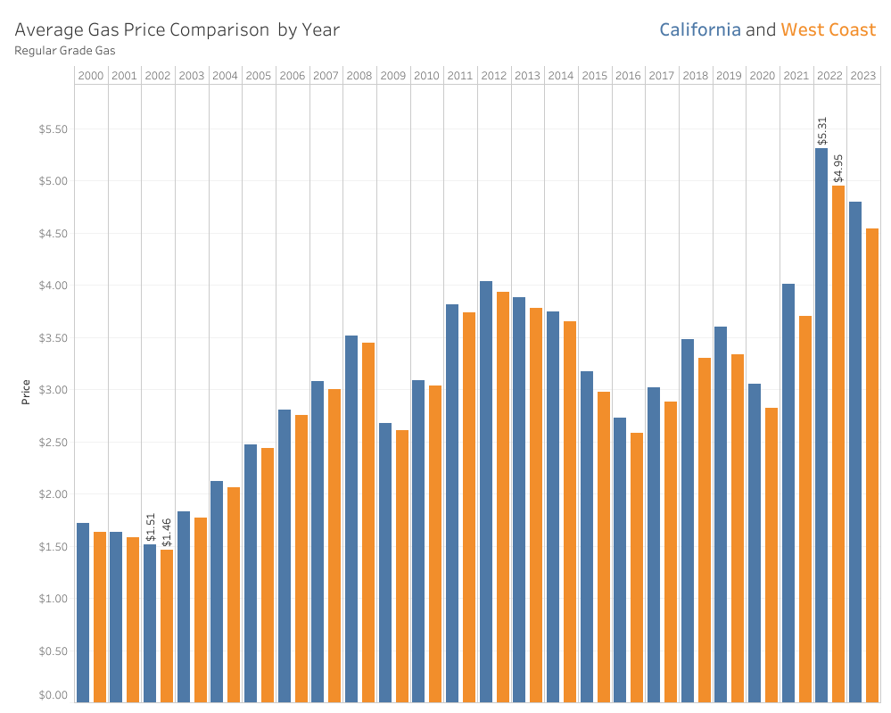

### California Line Chart Trend Comparison 2020-2023

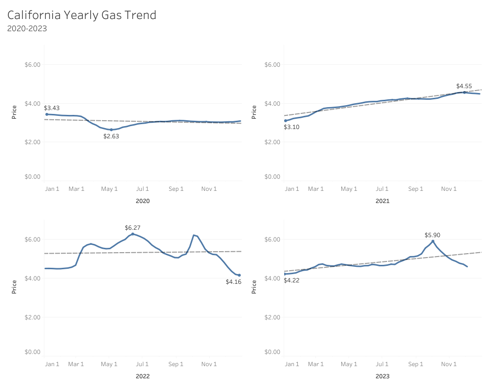

## Act

Data interpretation:

From the visualizations above, we can interpret data for the differentiation in gas prices between the regions and including California.

1. There is an overall trend of gas prices increasing over the years, with California and the West coast consistently above the average U.S. prices. Both regions exhibit similar trends, with prices moving up and down at the same intervals. However, there is a notable spike in gas prices from 2020 to 2022.
2. The East Coast tends to hover around the national average, while the Midwest consistently stays slightly below. The West Coast prices are considerably higher than the national average and have been increasing over the years, indicating a significant price disparity.

| years | national | west | percentage_difference |
| --- | --- | --- | --- |
| 2000 | $1.48 | $1.63 | 10.1% |
| 2005 | $2.27 | $2.43 | 7.0% |
| 2010 | $2.78 | $3.03 | 9.0% |
| 2015 | $2.43 | $2.98 | 22.6% |
| 2020 | $2.17 | $2.82 | 30.0% |
| 2023 | $3.54 | $4.54 | 28.2% |

3. The Tableau bar graph highlights a noticeable discrepancy in gas prices between California and the broader West Coast. California’s gas prices consistently trend higher than the regional average. Further analysis is needed to understand the reasons behind this consistent price differentiation..
4. The exploration into seasonal fluctuations in California’s gas prices, from 2020 to 2023, did not reveal specific patterns or trends. Gas prices seem to fluctuate independently of specific seasonal patterns.

### Further Observations

I recently came across an informative article from the [California Energy Commission](https://www.energy.ca.gov/data-reports/energy-insights/what-drives-californias-gasoline-prices) that sheds light on the intricacies behind the consistently higher gasoline prices in California. Here’s a breakdown:

- Global Crude Market: The article underscores the significant influence of the global crude oil market on California’s gasoline prices. Fluctuations and trends in the international crude oil market directly impact the costs incurred by the state.
- Geopolitical Issues: Geopolitical events introduce volatility into gas prices. The article points out that events like the Russian-Ukrainian conflict in 2022 caused a spike in prices due to disruptions in crude oil exports from Russia.
- Isolated Refinery Market: California’s reliance on a relatively isolated refinery market contributes to unique pricing dynamics. The limited connectivity and dependence on specific refineries make the state more susceptible to supply chain disruptions and price fluctuations.
- Cleaner Fuel Standards: California’s commitment to environmental sustainability is reflected in its cleaner fuel standards. While commendable, these standards necessitate specialized fuel blends, adding complexity and cost to the refining process and, consequently, contributing to higher gasoline prices.
- Environmental Program Costs: The implementation of robust environmental programs, designed to address air quality and climate change concerns, incurs additional costs for the industry. These costs, in turn, impact the final retail price of gasoline in California.
- Taxes: The article highlights the role of state taxes in contributing to the higher gas prices in California. The state imposes higher taxes on gasoline, further elevating the overall cost borne by consumers.

An intriguing revelation from the article is that more than two-thirds of the crude oil used in California comes from out-of-state sources. Specifically, 56.2% is imported from foreign countries, 14.9% is sourced from Alaska, and only 28.9% is produced within California.

The article also notes that California residents pay, on average, $1.23 per gallon more than the national average for gasoline. This significant disparity underscores the multitude of factors at play in the state’s gasoline pricing structure.

In conclusion, the California Energy Commission’s analysis provides valuable insights into the complexities of California’s gasoline pricing, offering a nuanced understanding of the interplay between global market forces, geopolitical events, and regional factors.